# Homework 4 - CP - PDP

I've chosen `Alcohol Effects On Study` dataset from Kaggle competition. For this particular homework I've used only `Maths.csv` dataframe. My prediction model of choice is XGBRegressor which is a tree-based ensemble regression model. Model's task is to predict final grade marked as "G3" based on other observations. Target values spans from 0 to 20.

## TASK 1

We are consdering a model: f(x1, x2) = (x1 + x2)^2

And we assume that: x1, x2 ~ U[-1,1] and x1=x2 (full dependency)

Ex_2 [x_2] = 0 Ex_2 [x_2^2] = integral from 0 to 1 of t^2 dt = 1/3

g_pd(z) = Ex_2[(z+x_2)^2] = Ex_2[(z^2 + 2zx_2 + x_2^2] = Ex_2[(z^2 + 2z*0 + x_2^2] = z^2 + 1/3

Our max and min values are then 4/3 and 1/3.

## TASK 2

# (2)

This task was completed with (*) own implementation of Ceteris Paribus.

For this and most of the future tasks I've chosen two samples that our model predicts as 15 and 12 respectively. When analyzing it with our implementation of CP algorithm we observe that most of the predictions are based on previous grades (features G1 and G2), and grades from second year have the most impact on prediction as the plot for CP is very steep.

[figure not shown]

Other features have small if any impact on model prediction, we can observe some fractional increase or decrease in model prediction, but in the end whole plot is farely flat. Out of all features that aren't representing previous grades the biggest impact on prediction is from features of `age` and `absences`.

[figure not shown]

# (3)

It was difficult to find two samples of diffrent CP profiles that had consistent fall in its prediction while the profile for the same feature on the other sample is clearly rising. In my selected samples I've found the most visible difference for `G1` feature where for the first sample prediction profile is falling in the middle of the distribution and for the second sample it's steadily rising.

[figure not shown]

To presented some other examples I've also randomly sampled some of the entries from the dataset such that their CP profiles for less impactfull features would also be different.

[figure not shown]

# (4)

This task was completed with (*) own implementation of PDP.

Global explanations of PDP profile showed that `G2` is really the most impactfull feature on model's prediction. It was also easier to see that there exist many more pairs of samples that CP profiles are different when it comes to their rise and fall in predicted `G3` feature when the value of the currently considered feature is changing. Still features different then `G1` and `G2` still have very flat profile on average.

[figure not shown]

# (5)

I've compared the `XGBRegressor` model with `LinearRegression` model with PDP profiles. Profiles are clearly linear functions (duh) and doesn't provide as much information as forest method. One thing that we can see here is how different features affect predictions on average. For example `dalc` and `age` features have a falling trend while the `g1` and `g2` profiles have rising trend. But it doesn't suprise as at all since these rising and falling trends just represent if the coefficient next to the feature variable is positive or negative.

[figure not shown]

## APPENDIX

```python
# https://www.kaggle.com/datasets/08163f86754da93458b7dfb3e1c80258069edd817a00db655f3ccc3da37c87b5?resource=download

# Download Maths.csv dataset from this link and put it into notebook directory.

import dalex as dx
import xgboost as xgb
import shap
import lime

import sklearn

import pandas as pd
import numpy as np
import matplotlib.pyplot as plt

import warnings
warnings.filterwarnings("ignore")
```

```python
import platform
print(f'Python {platform.python_version()}')
{package.__name__: package.__version__ for package in [dx, xgb, shap, sklearn, pd, np]}
```

```
Python 3.10.6
```

```
{'dalex': '1.5.0',
 'xgboost': '1.6.2',
 'shap': '0.41.0',
 'sklearn': '1.1.2',
 'pandas': '1.5.1',
 'numpy': '1.23.2'}
```

# Load data

```python
maths = pd.read_csv('Maths.csv')
maths.describe()
```

|  | age | Medu | Fedu | traveltime | studytime | failures | famrel | freetime | goout | Dalc | Walc | health | absences | G1 | G2 | G3 |
| --- | --- | --- | --- | --- | --- | --- | --- | --- | --- | --- | --- | --- | --- | --- | --- | --- |
| count | 395.000000 | 395.000000 | 395.000000 | 395.000000 | 395.000000 | 395.000000 | 395.000000 | 395.000000 | 395.000000 | 395.000000 | 395.000000 | 395.000000 | 395.000000 | 395.000000 | 395.000000 | 395.000000 |
| mean | 16.696203 | 2.749367 | 2.521519 | 1.448101 | 2.035443 | 0.334177 | 3.944304 | 3.235443 | 3.108861 | 1.481013 | 2.291139 | 3.554430 | 5.708861 | 10.908861 | 10.713924 | 10.415190 |
| std | 1.276043 | 1.094735 | 1.088201 | 0.697505 | 0.839240 | 0.743651 | 0.896659 | 0.998862 | 1.113278 | 0.890741 | 1.287897 | 1.390303 | 8.003096 | 3.319195 | 3.761505 | 4.581443 |
| min | 15.000000 | 0.000000 | 0.000000 | 1.000000 | 1.000000 | 0.000000 | 1.000000 | 1.000000 | 1.000000 | 1.000000 | 1.000000 | 1.000000 | 0.000000 | 3.000000 | 0.000000 | 0.000000 |
| 25% | 16.000000 | 2.000000 | 2.000000 | 1.000000 | 1.000000 | 0.000000 | 4.000000 | 3.000000 | 2.000000 | 1.000000 | 1.000000 | 3.000000 | 0.000000 | 8.000000 | 9.000000 | 8.000000 |
| 50% | 17.000000 | 3.000000 | 2.000000 | 1.000000 | 2.000000 | 0.000000 | 4.000000 | 3.000000 | 3.000000 | 1.000000 | 2.000000 | 4.000000 | 4.000000 | 11.000000 | 11.000000 | 11.000000 |
| 75% | 18.000000 | 4.000000 | 3.000000 | 2.000000 | 2.000000 | 0.000000 | 5.000000 | 4.000000 | 4.000000 | 2.000000 | 3.000000 | 5.000000 | 8.000000 | 13.000000 | 13.000000 | 14.000000 |
| max | 22.000000 | 4.000000 | 4.000000 | 4.000000 | 4.000000 | 3.000000 | 5.000000 | 5.000000 | 5.000000 | 5.000000 | 5.000000 | 5.000000 | 75.000000 | 19.000000 | 19.000000 | 20.000000 |

# Prepare data

```python
from sklearn.model_selection import train_test_split
from sklearn.preprocessing import StandardScaler

RANDOM_STATE = 21
CURRENT = "G3"
categorical_columns = ["school", "sex", "address", "famsize", "Pstatus", "Mjob", "Fjob", "reason", "guardian",
                       "schoolsup", "famsup", "paid", "activities", "nursery", "higher", "internet", "romantic"]
X = maths.drop(columns=CURRENT)
X = pd.get_dummies(X, columns = categorical_columns, drop_first=True)
y = maths[CURRENT]

X_train, X_test, y_train, y_test = train_test_split(X, y, train_size=0.8, random_state=RANDOM_STATE)
```

```python
model = xgb.XGBRegressor()
model.fit(X_train, y_train)

test_score = model.score(X_test, y_test)
train_score = model.score(X_train, y_train)
name = type(model).__name__
print(f"Accuracy of {name} model:\nTrain set: {train_score}\nTest set: {test_score}")
```

```
Accuracy of XGBRegressor model:
Train set: 0.9999999302039252
Test set: 0.8999616768096649
```

# Own implementations

```python
class CP:
    def __init__(self, model, method):
        self.model = model
        self.method = method
        self.data = None
        self.prediction = None
        self.x = None
        self.origin = None
        self.column = None

    def predict_profile(self, _observation, column, span, n_samples=100):
        self.x = np.linspace(span[0], span[1], num=n_samples, endpoint=True)
        self.data = []
        self.origin = _observation[column]
        self.column = column

        observation = _observation.copy()

        self.prediction = self.method(self.model, pd.DataFrame([observation], index=[0]))

        fake_data = []
        indexes = []
        for idx, val in enumerate(self.x):
            observation[column] = val
            indexes.append(idx)
            fake_data.append(observation.copy())
        self.data = np.array(self.method(self.model, pd.DataFrame(fake_data, index=indexes)))

    def plot(self, color="blue"):
        fig, ax = plt.subplots()
        ax.plot(self.x, self.data, color=color)
        ax.set(ylim=(0,20))
        plt.title(self.column)

        ax.scatter(self.origin, self.prediction, color='y', marker='D',linewidths=4)


class PDP:
    def __init__(self, model, method):
        self.cp = CP(model, method)
        self.x = None
        self.data = None
        self.alt_data = None
        self.exact_values = None
        self.column = None

    def predict_profile(self, observations, column, span, n_samples=100):
        self.data = []
        self.column = column

        for idx, obs in observations.iterrows():
            self.cp.predict_profile(obs, column, span, n_samples=n_samples)
            self.data.append(self.cp.data)

        self.x = self.cp.x
        self.alt_data_raw = np.array(self.data)
        self.alt_data = np.mean(self.alt_data_raw, axis=0)

    def plot(self):
        fig, ax = plt.subplots()
        ax.plot(self.x, self.alt_data)
        ax.set(ylim=(0,20))
        plt.title(self.column)
        for entry in self.data:
            ax.plot(self.x, entry, alpha=0.1)
```

```python
column_span_nsamples = [
    ["age", (15,22), 22-14],
    ["Medu", (0,4), 15],
    ["Fedu", (0,4), 15],
    ["traveltime", (1,4), 12],
    ["studytime", (1,4), 12],
    ["failures", (0,3), 12],
    ["famrel", (1,5), 15],
    ["freetime", (1,5), 15],
    ["goout", (1,5), 15],
    ["Dalc", (1,5), 15],
    ["Walc", (1,5), 15],
    ["health", (1,5), 15],
    ["absences", (0,75), 76],
    ["G1", (3,19), 34],
    ["G2", (3,19), 34],
]

sample_first = 21
sample_second = 305
```

```python
X.iloc[sample_first]
```

```
age                  15
Medu                  4
Fedu                  4
traveltime            1
studytime             1
failures              0
famrel                5
freetime              4
goout                 2
Dalc                  1
Walc                  1
health                5
absences              0
G1                   12
G2                   15
school_MS             0
sex_M                 1
address_U             1
famsize_LE3           0
Pstatus_T             1
Mjob_health           1
Mjob_other            0
Mjob_services         0
Mjob_teacher          0
Fjob_health           1
Fjob_other            0
Fjob_services         0
Fjob_teacher          0
reason_home           0
reason_other          1
reason_reputation     0
guardian_mother       0
guardian_other        0
schoolsup_yes         0
famsup_yes            1
paid_yes              1
activities_yes        0
nursery_yes           1
higher_yes            1
internet_yes          1
romantic_yes          0
Name: 21, dtype: int64
```

```python
X.iloc[sample_second]
```

```
age                  18
Medu                  2
Fedu                  4
traveltime            1
studytime             2
failures              1
famrel                4
freetime              4
goout                 3
Dalc                  1
Walc                  1
health                3
absences              8
G1                   14
G2                   12
school_MS             0
sex_M                 0
address_U             1
famsize_LE3           0
Pstatus_T             1
Mjob_health           0
Mjob_other            0
Mjob_services         1
Mjob_teacher          0
Fjob_health           0
Fjob_other            0
Fjob_services         0
Fjob_teacher          0
reason_home           0
reason_other          0
reason_reputation     1
guardian_mother       0
guardian_other        1
schoolsup_yes         0
famsup_yes            1
paid_yes              1
activities_yes        1
nursery_yes           1
higher_yes            1
internet_yes          1
romantic_yes          0
Name: 305, dtype: int64
```

```python
model.predict(X.iloc[[sample_first, sample_second]])
```

```
array([15.000054, 12.00045 ], dtype=float32)
```

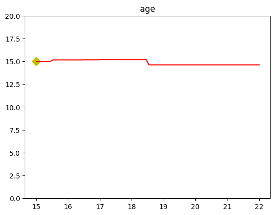

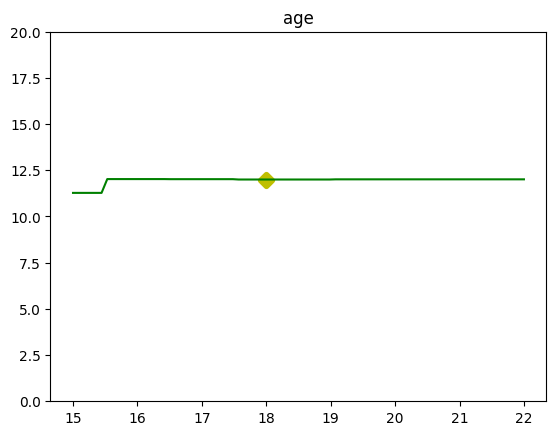

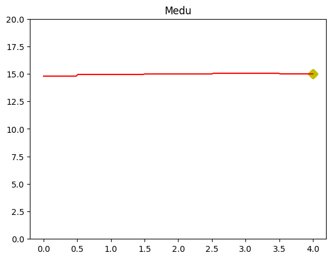

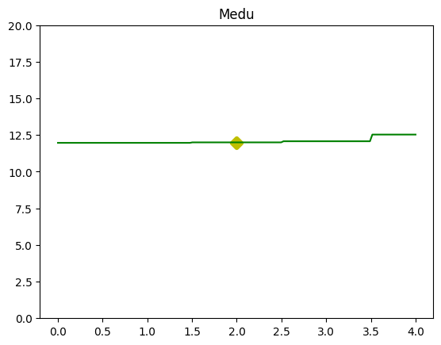

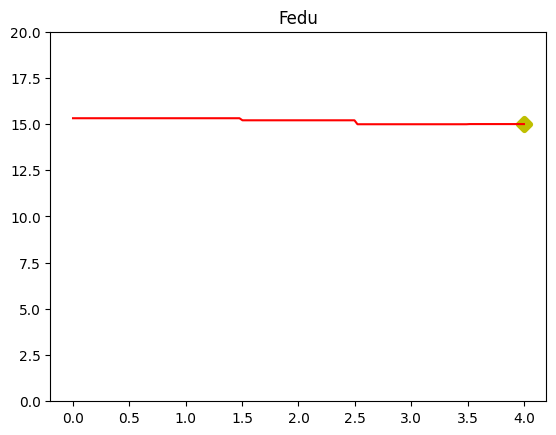

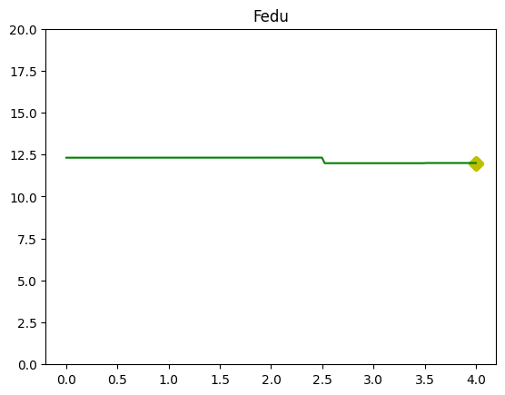

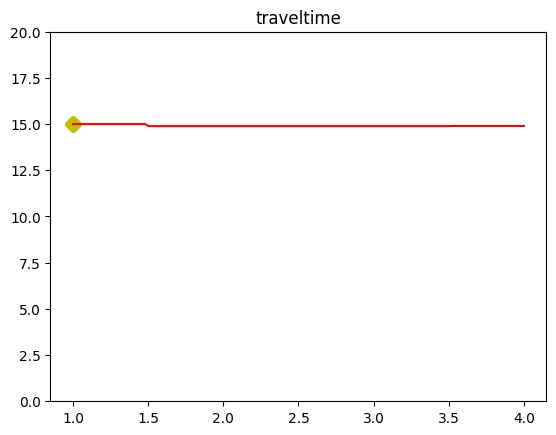

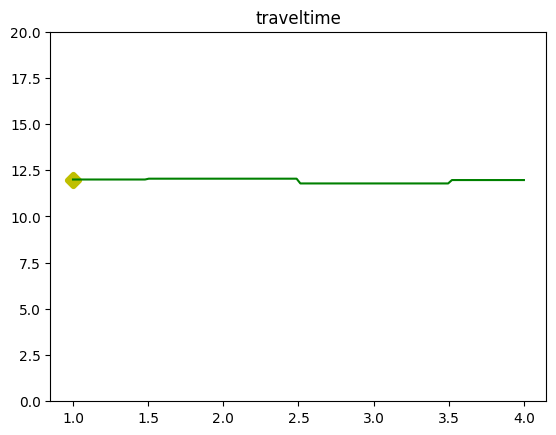

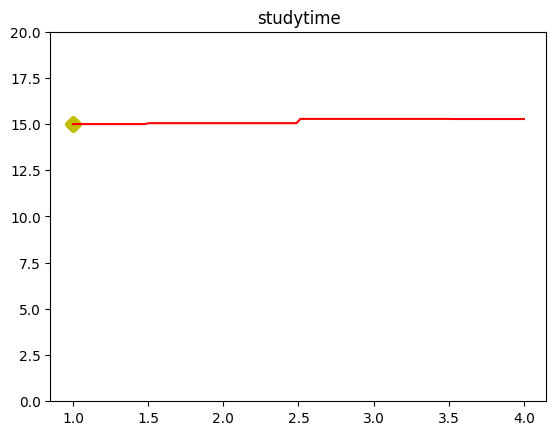

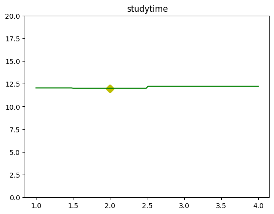

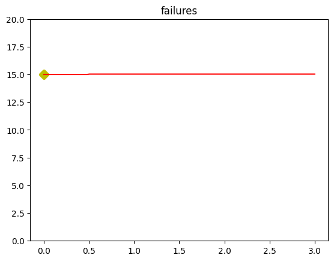

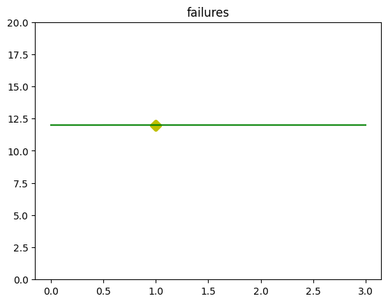

[18 more figures not shown]

```python
catering_pasibus = CP(model, lambda m, d: m.predict(d))

for data in column_span_nsamples:
    catering_pasibus.predict_profile(X.iloc[sample_first], data[0], data[1], n_samples=data[2]*10)
    catering_pasibus.plot(color="red")
    catering_pasibus.predict_profile(X.iloc[sample_second], data[0], data[1], n_samples=data[2]*10)
    catering_pasibus.plot(color="green")
```

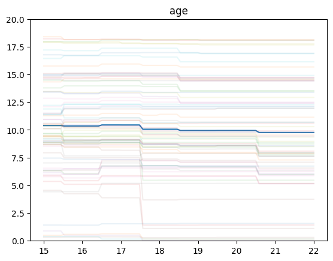

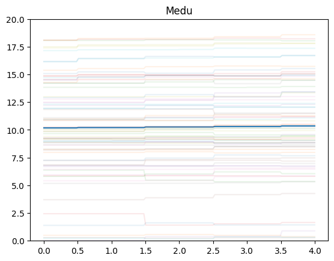

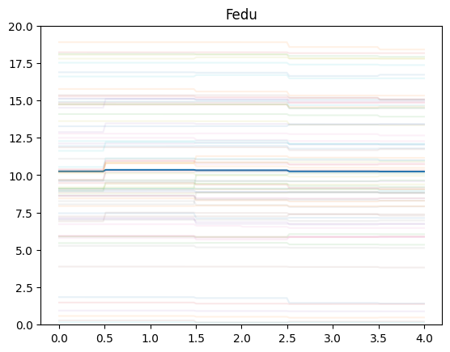

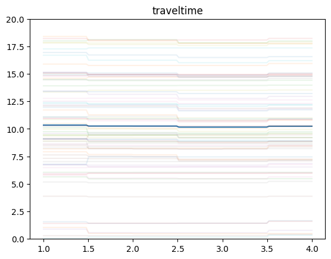

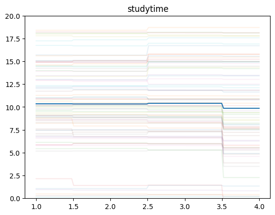

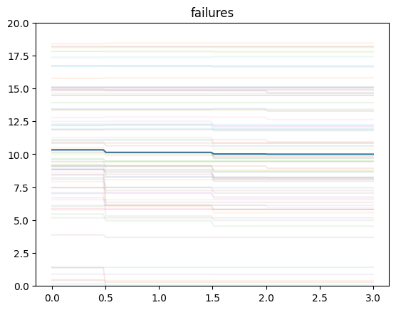

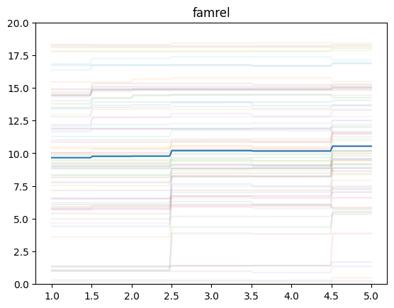

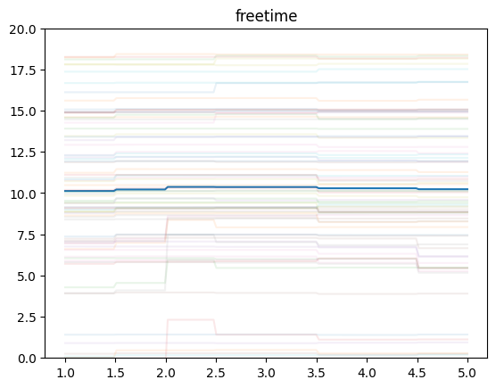

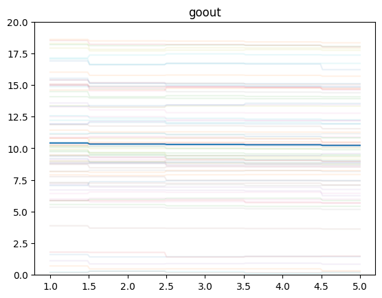

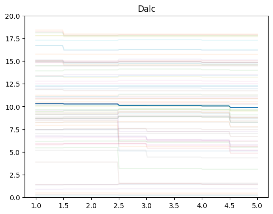

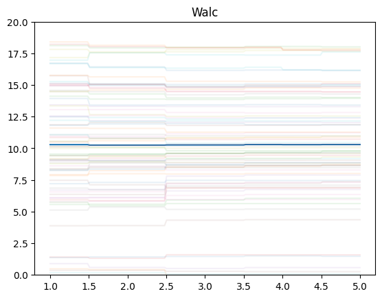

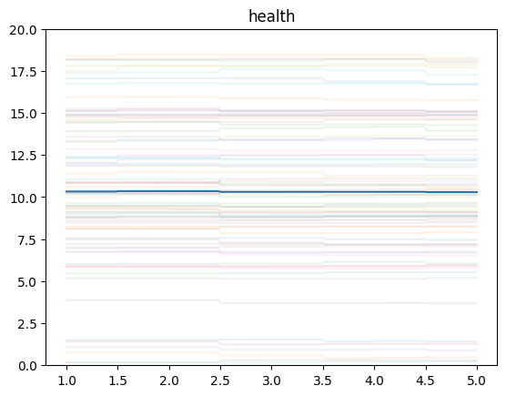

[3 more figures not shown]

```python
pdp = PDP(model, lambda m, d: m.predict(d))
for data in column_span_nsamples:
    pdp.predict_profile(X_test.iloc[:100], data[0], data[1], n_samples=data[2]*10)
    pdp.plot()
```